# Cardiovascular Disease Analysis

*Project Foundations of Probability and Statistics*

*Marco Sallustio (906149), Yasmin Bouhdada(837389), Alessandro Rota(798050)*

# Index

1. Library
2. Importing Data
3. Target Variable
4. Age Analysis
5. Sex Analysis
6. Chest Pain Analysis
7. Rest Blood Pressure Analysis
8. Cholestrol Analysis
9. Fasting Blood Sugar Analysis
10. Resting ECG Result
11. Maximum Heart Rate
12. Exercise Induced Angina
13. OldPeak Analysis
14. Slope Analysis
15. Ca Analysis
16. Test
    1. Chi-Squared Test
    2. Shapiro-Wilk Test
17. Correlation
18. Linear Regression
    1. Age-Trestbps
    2. Age-Chol
    3. Age-Heart Rate
    4. Age-Oldpeak
    5. Chol-Trestbps
    6. Chol-Heart Rate
    7. Chol-Oldpeak
    8. Trestbps-Heart Rate
    9. Trestbps-Oldpeak
    10. Oldpeak-Heart Rate
19. Residuals

# Library

```r
library(ggplot2)
library(ggforce)
library(corrplot)
```

# Importing Data

Heart disease is a catch-all phrase for a variety of conditions that affect the heart’s structure and function. Coronary heart disease is a type of heart disease that develops when the arteries of the heart cannot deliver enough oxygen-rich blood to the heart. It is the leading cause of death in the United States.

Now we will carry out an analysis in which we try to understand the causes that lead to a heart attack, analyzing different parameters like the heart rate during exercise or the cholesterol levels in the blood.

The dataset was downloaded from the following link: https://www.kaggle.com/datasets/johnsmith88/heart-disease-dataset

```r
heart<-read.csv("heart.csv")
head(heart)
```

```
##   age sex cp trestbps chol fbs restecg thalach exang oldpeak slope ca thal
## 1  52   1  0      125  212   0       1     168     0     1.0     2  2    3
## 2  53   1  0      140  203   1       0     155     1     3.1     0  0    3
## 3  70   1  0      145  174   0       1     125     1     2.6     0  0    3
## 4  61   1  0      148  203   0       1     161     0     0.0     2  1    3
## 5  62   0  0      138  294   1       1     106     0     1.9     1  3    2
## 6  58   0  0      100  248   0       0     122     0     1.0     1  0    2
##   target
## 1      0
## 2      0
## 3      0
## 4      0
## 5      0
## 6      1
```

```r
dim(heart)
```

```
## [1] 1025   14
```

Description of dataset variables:

```r
str(heart)
```

```
## 'data.frame':    1025 obs. of  14 variables:
##  $ age     : int  52 53 70 61 62 58 58 55 46 54 ...
##  $ sex     : int  1 1 1 1 0 0 1 1 1 1 ...
##  $ cp      : int  0 0 0 0 0 0 0 0 0 0 ...
##  $ trestbps: int  125 140 145 148 138 100 114 160 120 122 ...
##  $ chol    : int  212 203 174 203 294 248 318 289 249 286 ...
##  $ fbs     : int  0 1 0 0 1 0 0 0 0 0 ...
##  $ restecg : int  1 0 1 1 1 0 2 0 0 0 ...
##  $ thalach : int  168 155 125 161 106 122 140 145 144 116 ...
##  $ exang   : int  0 1 1 0 0 0 0 1 0 1 ...
##  $ oldpeak : num  1 3.1 2.6 0 1.9 1 4.4 0.8 0.8 3.2 ...
##  $ slope   : int  2 0 0 2 1 1 0 1 2 1 ...
##  $ ca      : int  2 0 0 1 3 0 3 1 0 2 ...
##  $ thal    : int  3 3 3 3 2 2 1 3 3 2 ...
##  $ target  : int  0 0 0 0 0 1 0 0 0 0 ...
```

```r
heart$target<-as.numeric(heart$target)
```

# Target Variable

```r
q=table(heart$target)
```

From this plot we can see that in our dataset there are more cases of heart attack(Target=1) than cases in which it did not occur(Target=0).

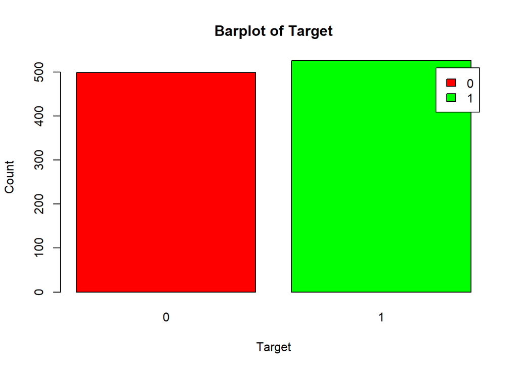

```r
barplot(q,
       col=c("red","green"),
       legend=rownames(q),
       xlab="Target",
       ylab="Count",
       main="Barplot of Target")
```

# Age analysis

Minimum age is 29 and Maximum age is 77.

```r
range(heart$age)
```

```
## [1] 29 77
```

Average age of Population is 54.43.

```r
summary(heart$age)
```

```
##    Min. 1st Qu.  Median    Mean 3rd Qu.    Max.
##   29.00   48.00   56.00   54.43   61.00   77.00
```

```r
age_interval <- c(29, 35, 41, 47, 53, 59, 65, 71, 77)
age_abs_freq <- table(cut(heart$age, age_interval))
age_rel_freq <- round(age_abs_freq/sum(age_abs_freq),3)
age_summary <- cbind(age_abs_freq,cumsum(age_abs_freq), age_rel_freq,cumsum(age_rel_freq))
colnames(age_summary) <- c(
  "Absolute",
  "Cum. absolute",
  "Relative",
  "Cum. relative")
age_summary
```

```
##         Absolute Cum. absolute Relative Cum. relative
## (29,35]       21            21    0.021         0.021
## (35,41]       75            96    0.073         0.094
## (41,47]      154           250    0.151         0.245
## (47,53]      169           419    0.166         0.411
## (53,59]      293           712    0.287         0.698
## (59,65]      198           910    0.194         0.892
## (65,71]      102          1012    0.100         0.992
## (71,77]        9          1021    0.009         1.001
```

There is low negative correlation between age and dependent variable target. This shows that on increasing age probability of heart attack is decreasing.

```r
cor(heart$age,heart$target)
```

```
## [1] -0.2293236
```

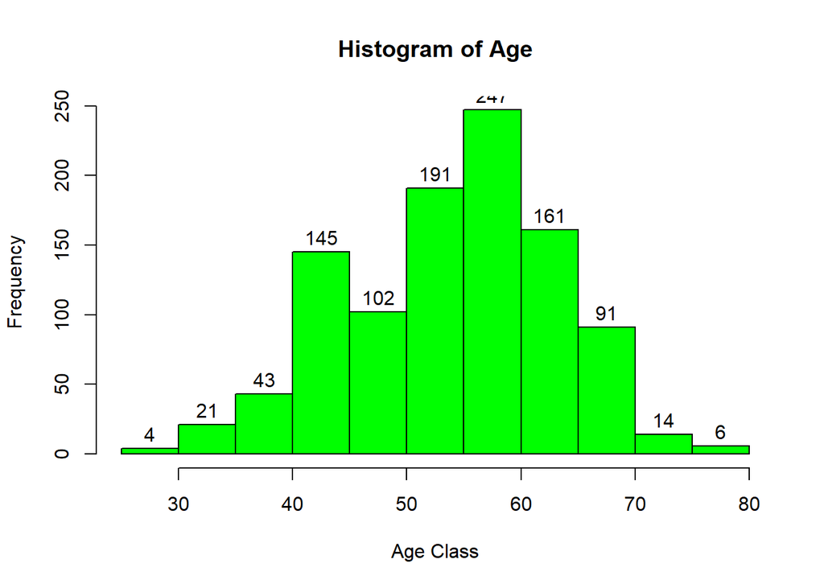

```r
hist(heart$age,labels=TRUE,main="Histogram of Age",xlab="Age Class",ylab="Frequency",col="green")
```

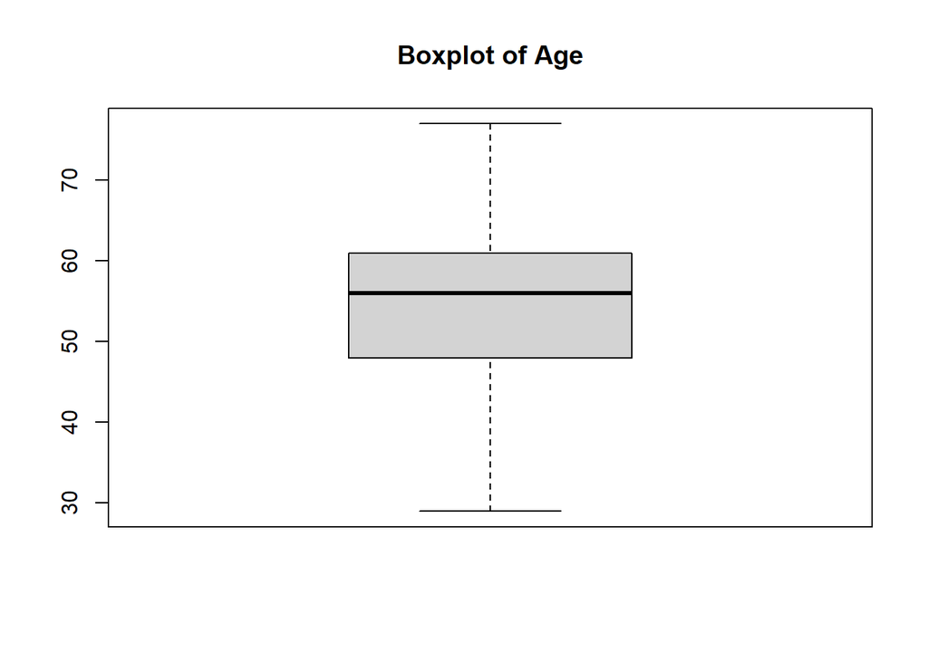

```r
boxplot(heart$age,vertical=TRUE,main="Boxplot of Age")
```

After fitting a smooth curve we can see that from age 30 to 60 probability of heart attack decrease and from 60 the curve reverses its trend. After 70 chance of heart attack is high.

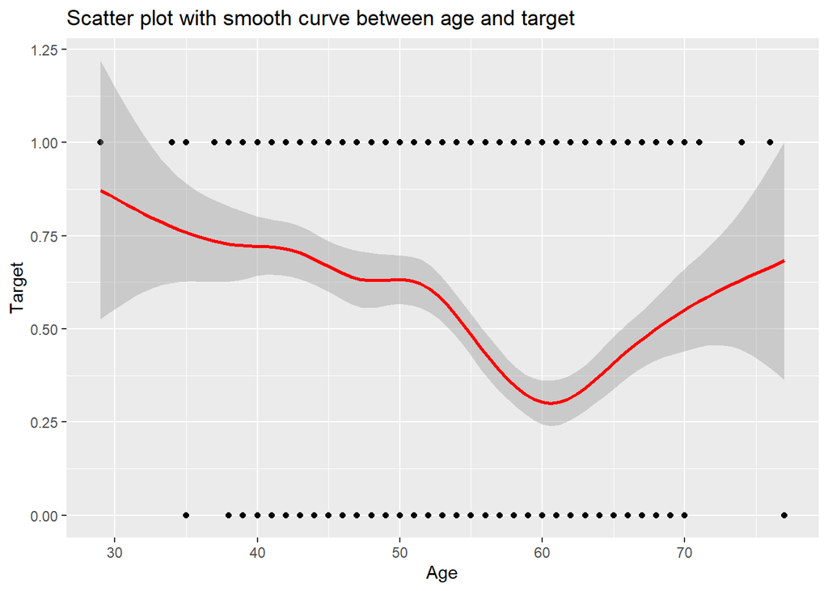

```r
a=ggplot(heart,aes(x=age,y=target))+geom_point()+geom_smooth(color="red")
b=a+scale_x_continuous(name="Age")+scale_y_continuous(name="Target")
b+ggtitle("Scatter plot with smooth curve between age and target")
```

# Sex Analysis

This variable has 2 category 0 represents female and 1 means male. For easier understanding let’s change the value of this column. F denotes female individuals and M denotes male individuals.

```r
heart$sex <-factor(heart$sex)
levels(heart$sex) <-c("F","M")
```

Out of 1025 Observations 312 of them are Female and 713 are male.

```r
table(heart$sex)
```

```
##
##   F   M
## 312 713
```

```r
a=table(heart$sex)
par(mfrow=c(1,2))
```

In barplot it is clearly visible that proportion of male is more as compared to female.

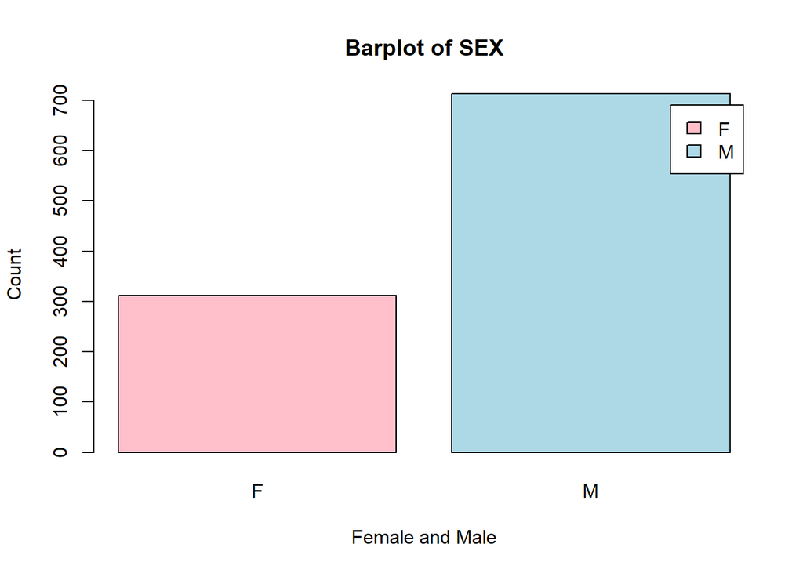

```r
barplot(a,
       col=c("pink","lightblue"),
       legend=rownames(a),
       xlab="Female and Male",
       ylab="Count",
       main="Barplot of SEX")
```

Also in Pie chart we can see that proportion of female is 30 % while male is 70%.

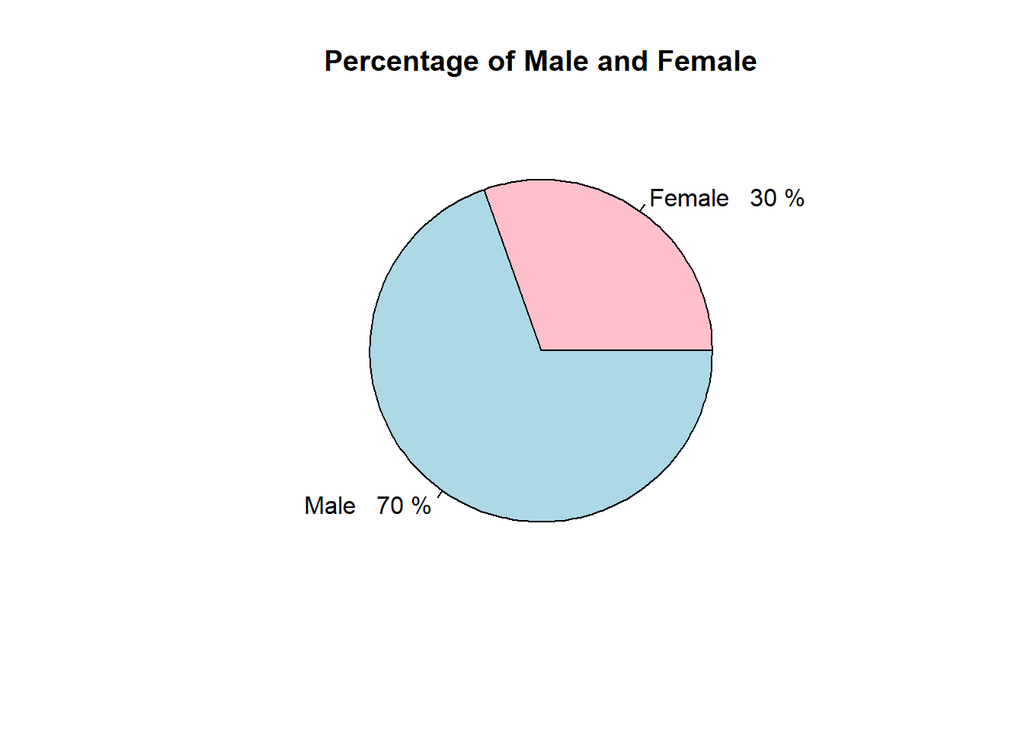

```r
pct=round(a/sum(a)*100)
lbs=paste(c("Female","Male")," ",pct,"%",sep=" ")
pie(a,labels=lbs,col=c("pink","lightblue"),main="Percentage of Male and Female")
```

```r
b=table(heart$sex,heart$target)
b
```

```
##
##       0   1
##   F  86 226
##   M 413 300
```

In side by side Barchart we can see that in case of not suffered with Heart Attack, Feamle is very less while more male has survived heart attack.

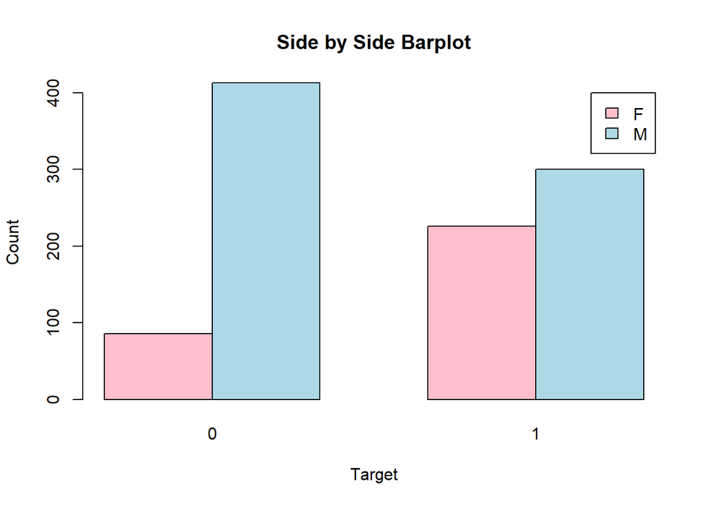

```r
barplot(b,
       col=c("pink","lightblue"),
       legend=rownames(b),
       beside=TRUE,
       xlab="Target",
       ylab="Count",
       main="Side by Side Barplot")
```

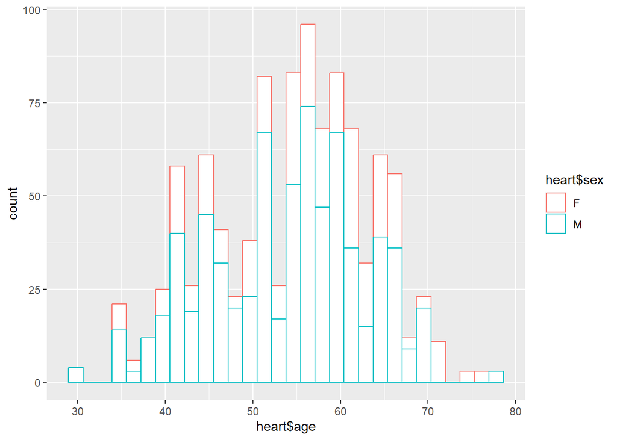

```r
ggplot(heart, aes(x=heart$age, color=heart$sex)) +
  geom_histogram(fill="white")
```

# Chest Pain Analysis

```r
heart$cp=factor(heart$cp)
d=table(heart$cp)
```

There is 4 category of Chest pain starting from 0 up to 3.

```r
d
```

```
##
##   0   1   2   3
## 497 167 284  77
```

In barplot it is clear that, People having Chest pain 0 are more followed by 2.

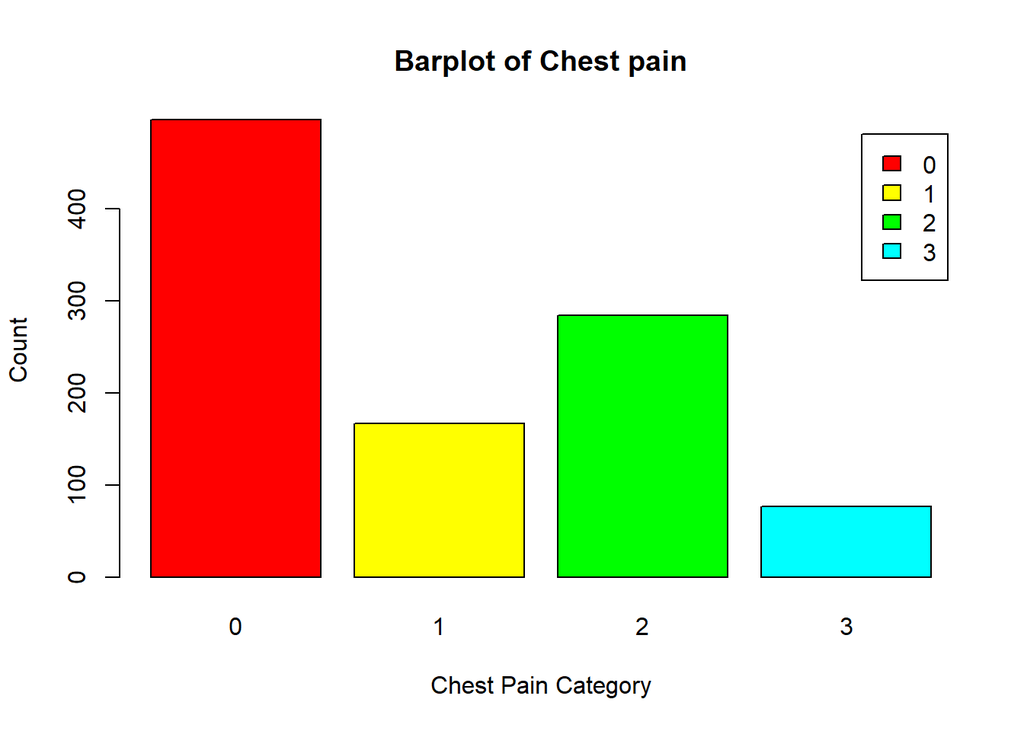

```r
barplot(d,
       col=rainbow(6),
       main="Barplot of Chest pain",
       xlab="Chest Pain Category",
       ylab="Count",
       legend=rownames(d))
```

We can Visualize through smooth curve between age and target that People having Chest Pain 0 and age from 40 to 65 are less likely to get heart attack.

People with chest pain 2 are more likely to get heart attack.

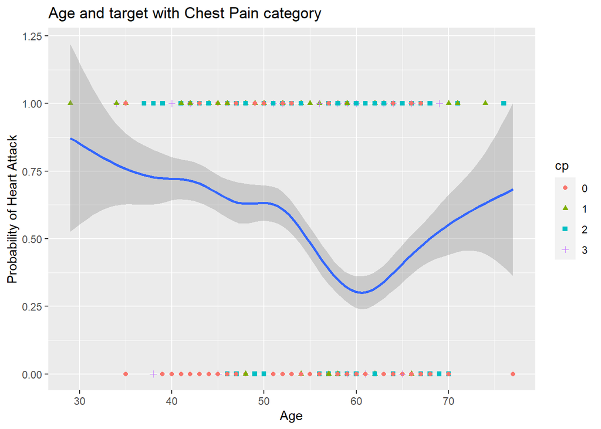

```r
e=ggplot(heart,aes(x=age,y=target))+geom_point(aes(shape=cp,color=cp))+geom_smooth()
e+scale_x_continuous(name="Age")+scale_y_continuous(name="Probability of Heart Attack")+ggtitle("Age and target with Chest Pain category")
```

# Rest Blood Pressure Analysis

Minimum RBP(Rest Blood Pressure) is 94 and Maximum is 200.

Average RBP is 131.6

```r
summary(heart$trestbps)
```

```
##    Min. 1st Qu.  Median    Mean 3rd Qu.    Max.
##    94.0   120.0   130.0   131.6   140.0   200.0
```

```r
trestbps_interval <- c(94,111,128,145,162,179,200)
tbs_abs_freq <- table(cut(heart$trestbps, trestbps_interval))
tbs_rel_freq <- round(tbs_abs_freq/sum(tbs_abs_freq),3)
tbs_summary <- cbind(tbs_abs_freq,cumsum(tbs_abs_freq), tbs_rel_freq,cumsum(tbs_rel_freq))
colnames(tbs_summary) <- c(
  "Absolute",
  "Cum. absolute",
  "Relative",
  "Cum. relative")
tbs_summary
```

```
##           Absolute Cum. absolute Relative Cum. relative
## (94,111]       123           123    0.121         0.121
## (111,128]      324           447    0.318         0.439
## (128,145]      386           833    0.379         0.818
## (145,162]      133           966    0.131         0.949
## (162,179]       35          1001    0.034         0.983
## (179,200]       17          1018    0.017         1.000
```

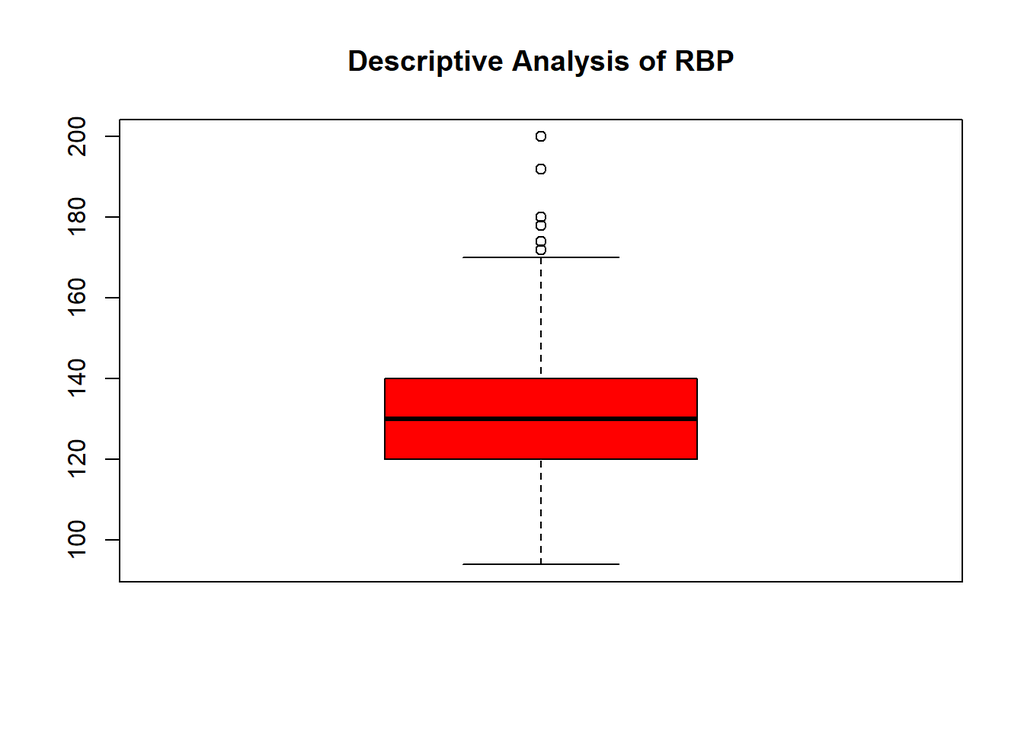

```r
boxplot(heart$trestbps,
       col="red",
       main="Descriptive Analysis of RBP",
       horizontal=FALSE)
```

```r
boxplot.stats(heart$trestbps)
```

```
## $stats
## [1]  94 120 130 140 170
##
## $n
## [1] 1025
##
## $conf
## [1] 129.013 130.987
##
## $out
##  [1] 180 178 174 180 192 200 178 192 180 200 192 172 180 174 178 180 200 180 178
## [20] 180 178 174 180 200 172 180 178 178 172 180
```

We can clearly see in Histogram, Maximum number of Population have Rest Blood Pressure between 120 and 140.

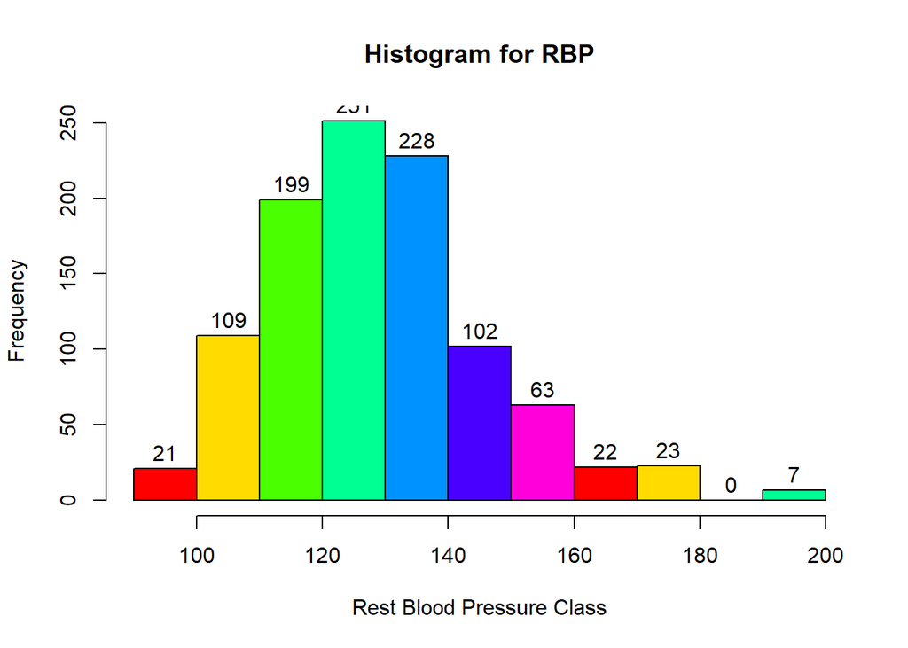

```r
hist(heart$trestbps,col=rainbow(7),
    main="Histogram for RBP",
    xlab="Rest Blood Pressure Class",
    ylab="Frequency",
    labels=TRUE)
```

People having RBP between 95 and 110 are more likely to get Heart Attack.

We can see in smooth curve probability of Heart Attack is decreasing after RBP 135.

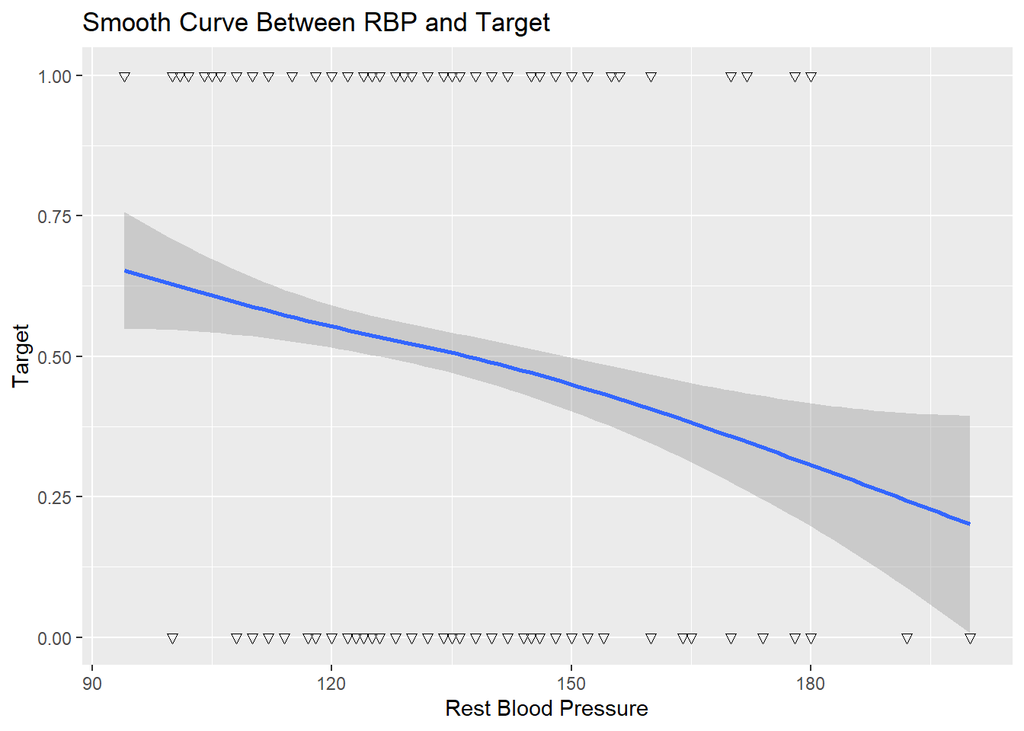

```r
f=ggplot(heart,aes(x=trestbps,y=target))+geom_point(shape=6)+geom_smooth()
f+scale_x_continuous(name="Rest Blood Pressure")+scale_y_continuous(name="Target")+ggtitle("Smooth Curve Between RBP and Target")
```

Comparison of Blood pressure across pain type:

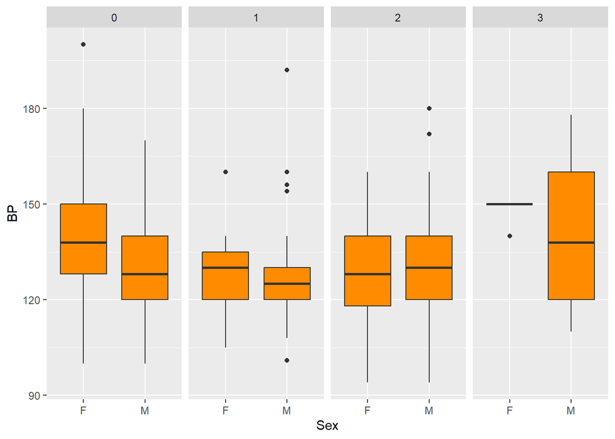

```r
ggplot(heart,aes(x=sex,y=trestbps))+
  geom_boxplot(fill="darkorange")+
  xlab("Sex")+
  ylab("BP")+
  facet_grid(~cp)
```

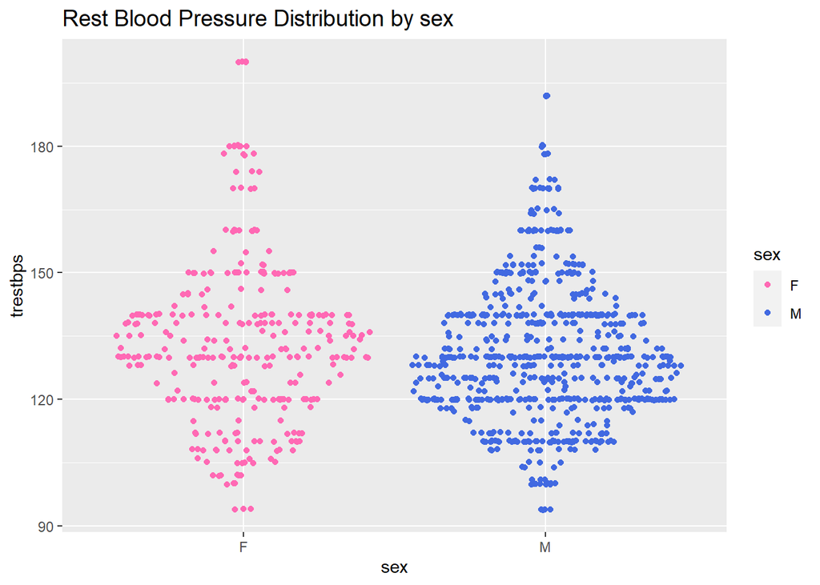

```r
ggplot(heart, aes(x=sex, y=trestbps, color=sex)) +
geom_sina()+
scale_color_manual(values=c('hotpink', "royalblue"))+
labs(title="Rest Blood Pressure Distribution by sex")+
theme(plot.title = element_text(size=14))
```

# Cholestrol Analysis

Minimum Cholestrol among patients is 126, Maxmum is 564 and Average Cholestrol is 246.

```r
summary(heart$chol)
```

```
##    Min. 1st Qu.  Median    Mean 3rd Qu.    Max.
##     126     211     240     246     275     564
```

```r
chol_interval <- c(126,188,250,312,374,436,498,564)
chol_abs_freq <- table(cut(heart$chol, chol_interval))
chol_rel_freq <- round(chol_abs_freq/sum(chol_abs_freq),3)
chol_summary <- cbind(chol_abs_freq,cumsum(chol_abs_freq), chol_rel_freq,cumsum(chol_rel_freq))
colnames(chol_summary) <- c(
  "Absolute",
  "Cum. absolute",
  "Relative",
  "Cum. relative")
chol_summary
```

```
##           Absolute Cum. absolute Relative Cum. relative
## (126,188]      109           109    0.107         0.107
## (188,250]      489           598    0.478         0.585
## (250,312]      330           928    0.323         0.908
## (312,374]       78          1006    0.076         0.984
## (374,436]       13          1019    0.013         0.997
## (436,498]        0          1019    0.000         0.997
## (498,564]        3          1022    0.003         1.000
```

We can see Boxplot for descriptive Analysis seperately for Male and Female. In boxplot it is also clear that Male has lower colestrol than Female.

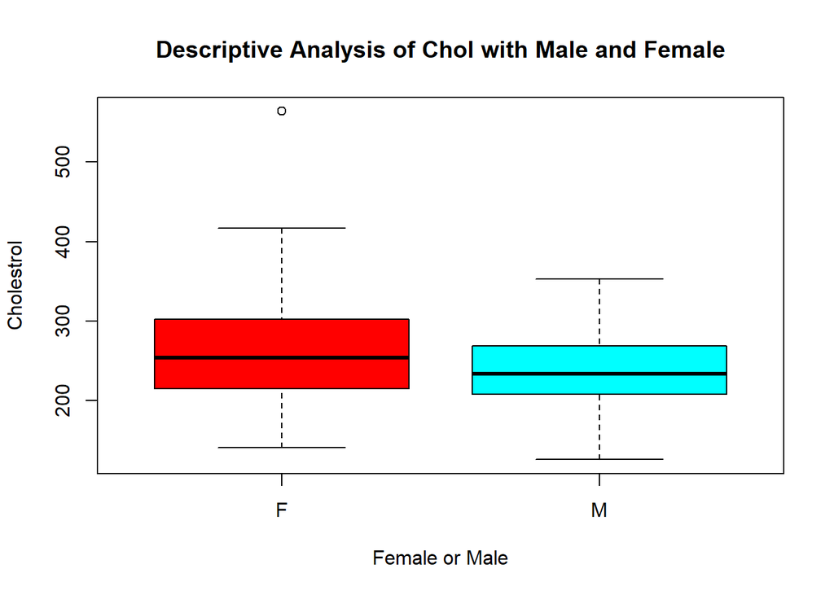

```r
boxplot(heart$chol~as.factor(heart$sex),col=rainbow(2),main="Descriptive Analysis of Chol with Male and Female",
       xlab="Female or Male",
       ylab="Cholestrol")
```

We can clearly see in Histogram that maximum population have cholestrol between 200 and 250 unit.

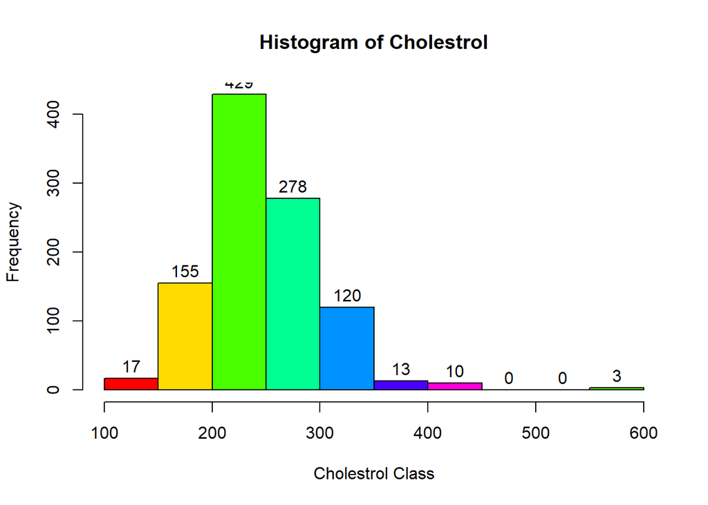

```r
hist(heart$chol,
    main="Histogram of Cholestrol",
    xlab="Cholestrol Class",
    ylab="Frequency",
    col=rainbow(7),labels=TRUE)
```

```r
heart$sex=as.factor(heart$sex)
```

In Smooth curve we can clearly see that probability of Heart attack is increasing after cholestrol level 300.

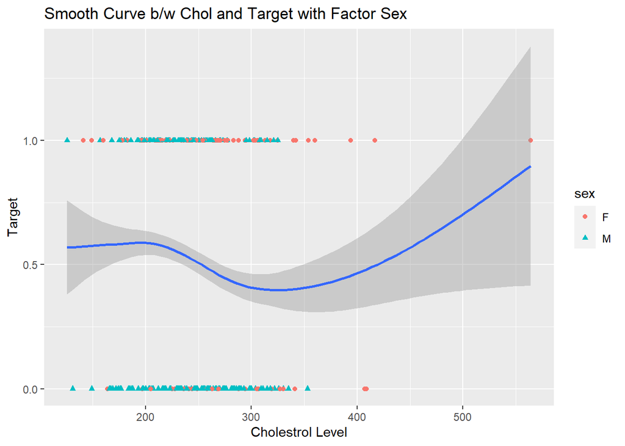

```r
ggplot(heart,aes(x=chol,y=target))+geom_point(aes(shape=sex,color=sex))+geom_smooth()+ggtitle("Smooth Curve b/w Chol and Target with Factor Sex")+scale_x_continuous(name="Cholestrol Level")+scale_y_continuous(name="Target")
```

In this plot the size of each point is adjusted according to the cholesterol level.

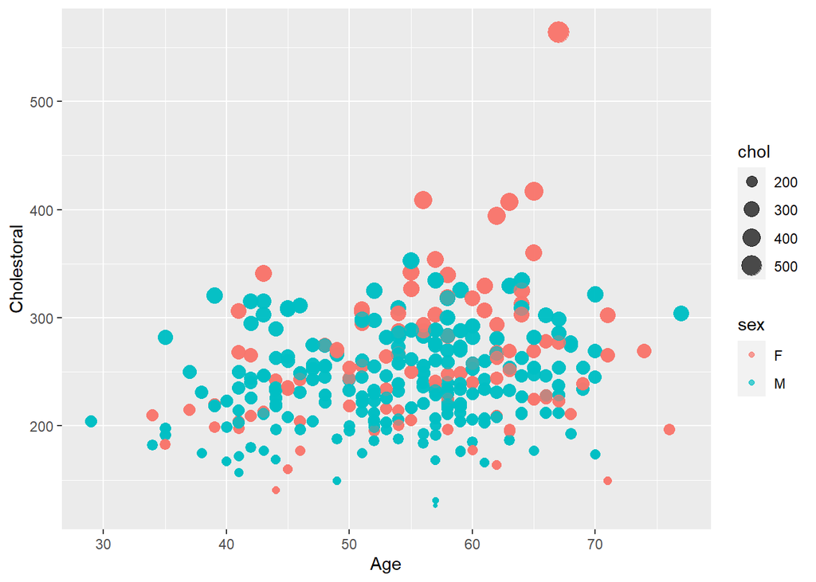

```r
ggplot(heart,aes(x=age,y=chol,color=sex, size=chol))+
  geom_point(alpha=0.7)+xlab("Age") +
  ylab("Cholestoral")+
  guides(fill = guide_legend(title = "Gender"))
```

Comparison of Cholestoral across pain type:

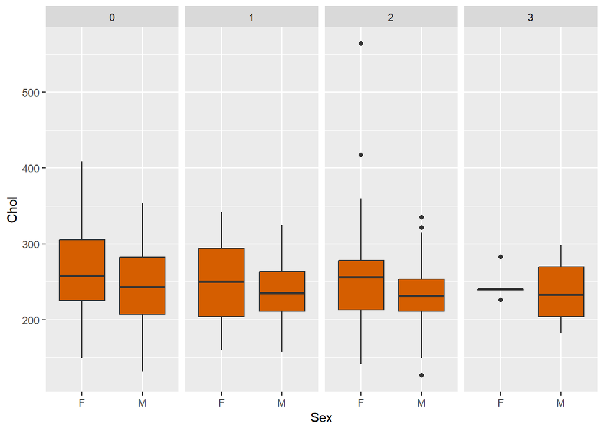

```r
ggplot(heart,aes(x=sex,y=chol))+
  geom_boxplot(fill="#D55E00")+
  xlab("Sex")+
  ylab("Chol")+
  facet_grid(~cp)
```

# Fasting Blood Sugar Analysis

This is a Categorical Variable in which 0 means level is less than 120 unit and 1 means it is greater than 120 unit.

```r
summary(heart$fbs)
```

```
##    Min. 1st Qu.  Median    Mean 3rd Qu.    Max.
##  0.0000  0.0000  0.0000  0.1493  0.0000  1.0000
```

```r
h=table(heart$fbs)
par(mfrow=c(1,2))
```

In Bar chart and Pie chart it is clearly visible that maximum(85% of the population) Peoples have FBS less than 120.

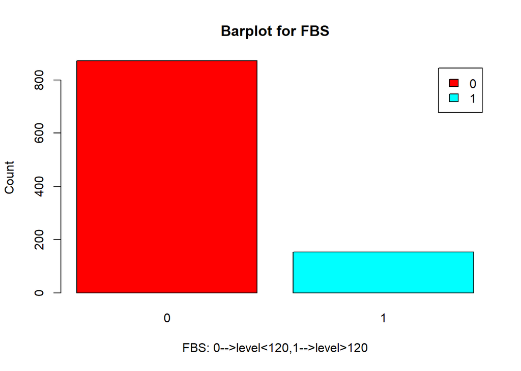

```r
barplot(h,
       main="Barplot for FBS",
       xlab="FBS: 0-->level<120,1-->level>120",
       ylab="Count",
       col=rainbow(2),
       legend=rownames(h))
```

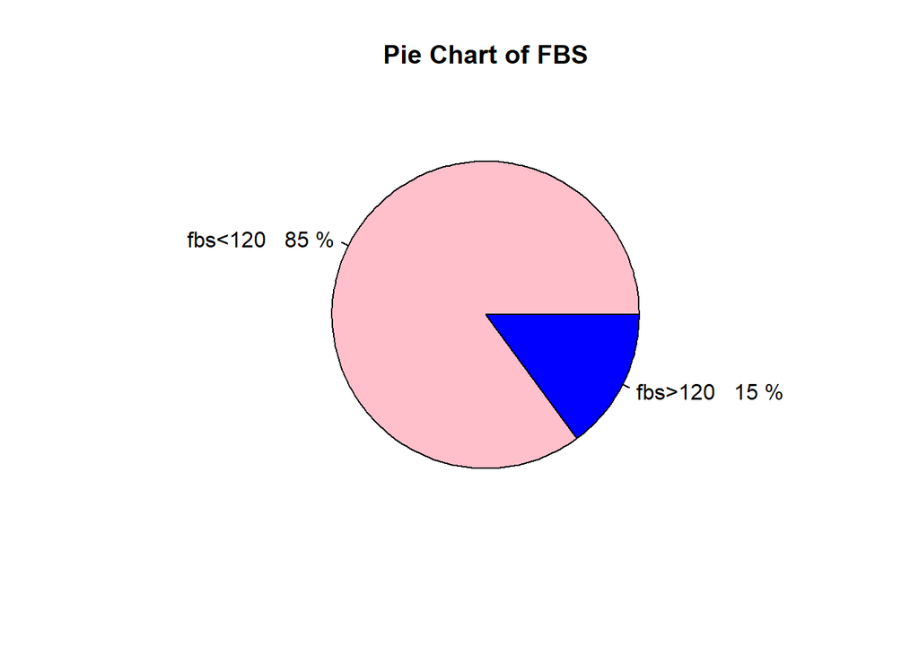

```r
pct=round(h/sum(h)*100)
lbs=paste(c("fbs<120","fbs>120")," ",pct,"%",sep=" ")
pie(h,lbs,main="Pie Chart of FBS",col=c("pink","blue"))
```

# Resting ECG result

There is 3 Category in this Variable 0,1 and 2.

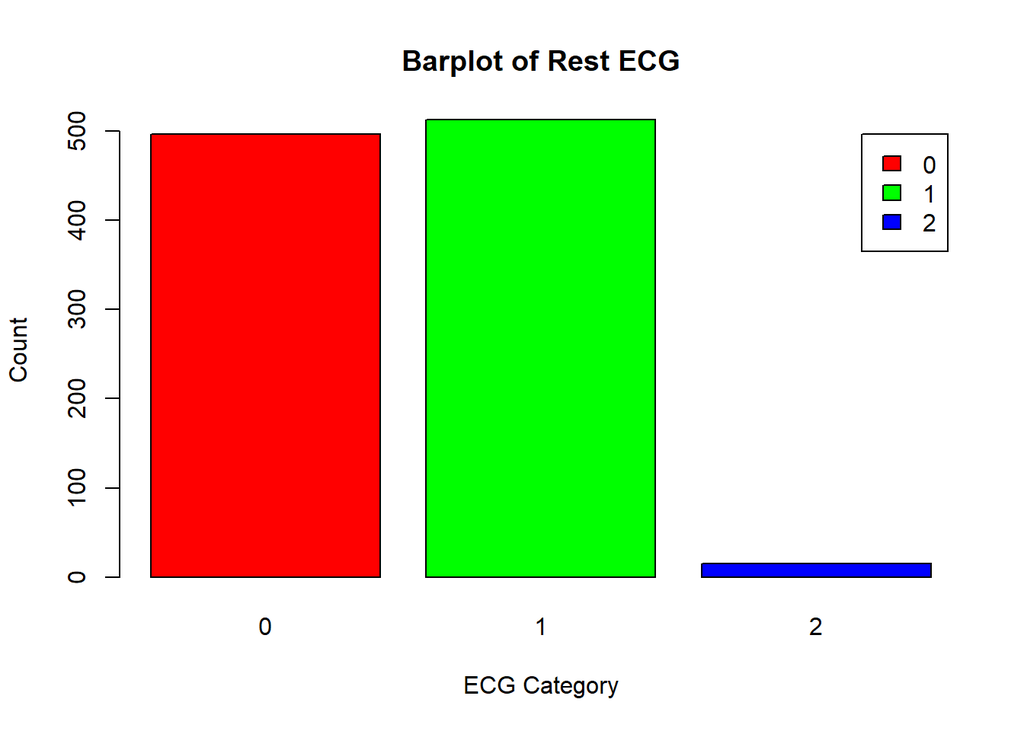

```r
j=table(heart$restecg)
barplot(j,
       main="Barplot of Rest ECG",
       xlab="ECG Category",
       ylab="Count",
       col=rainbow(3),legend=rownames(j))
```

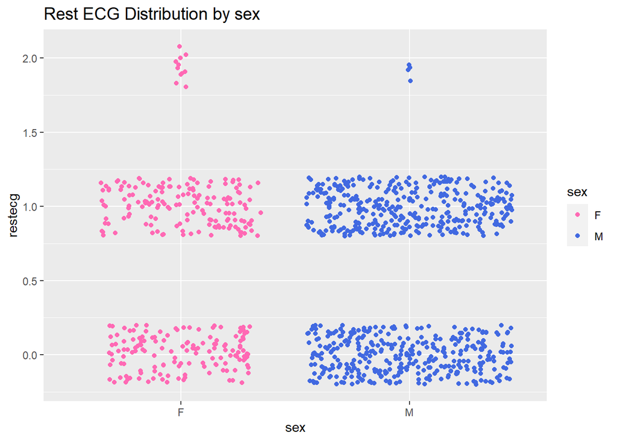

```r
ggplot(heart, aes(x=sex, y=restecg, color=sex)) +
geom_sina()+
scale_color_manual(values=c('hotpink', "royalblue"))+
labs(title="Rest ECG Distribution by sex")+
theme(plot.title = element_text(size=14))
```

# Maximum Heart Rate

This is continous data with minimum heart rate achieved 71 and maximum 202.

```r
summary(heart$thalach)
```

```
##    Min. 1st Qu.  Median    Mean 3rd Qu.    Max.
##    71.0   132.0   152.0   149.1   166.0   202.0
```

```r
thalach_age <- c(71,92,113,134,155,176,202)
thalach_abs_freq <- table(cut(heart$thalach, thalach_age))
thalach_rel_freq <- round(thalach_abs_freq/sum(thalach_abs_freq),3)
thalach_summary <- cbind(thalach_abs_freq,cumsum(thalach_abs_freq), thalach_rel_freq,cumsum(thalach_rel_freq))
colnames(thalach_summary) <- c(
  "Absolute",
  "Cum. absolute",
  "Relative",
  "Cum. relative")
thalach_summary
```

```
##           Absolute Cum. absolute Relative Cum. relative
## (71,92]          6             6    0.006         0.006
## (92,113]        74            80    0.072         0.078
## (113,134]      187           267    0.183         0.261
## (134,155]      292           559    0.286         0.547
## (155,176]      362           921    0.355         0.902
## (176,202]      100          1021    0.098         1.000
```

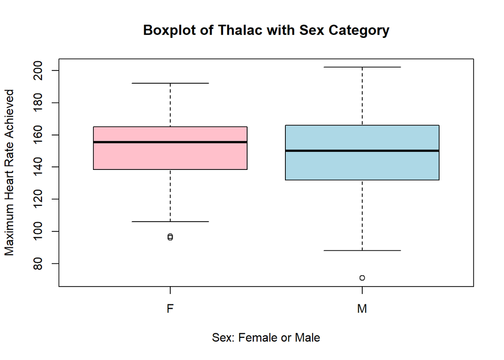

```r
boxplot(heart$thalach~as.factor(heart$sex),
       main="Boxplot of Thalac with Sex Category",
       xlab="Sex: Female or Male",
       ylab="Maximum Heart Rate Achieved",
       col=c("pink","lightblue"))
```

With correlation we can see how age is effecting Heart Rate. There is negative corelation between age and heart rate, this means on getting older Heart rate is decreasing which can also be seen clearly in smooth curve.

```r
cor(heart$age,heart$thalach)
```

```
## [1] -0.3902271
```

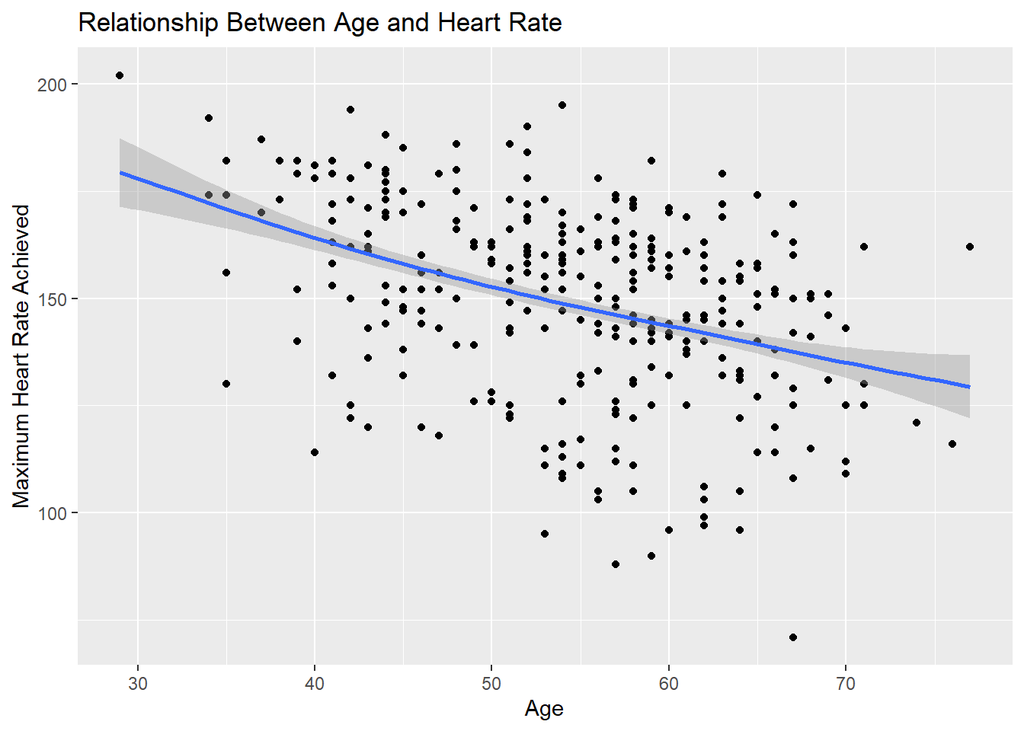

```r
ggplot(heart,aes(x=age,y=thalach))+geom_point()+geom_smooth()+
    scale_x_continuous(name="Age")+
    scale_y_continuous(name="Maximum Heart Rate Achieved")+
    ggtitle("Relationship Between Age and Heart Rate")
```

We can also see scatter plot and smooth curve between Heart rate and Heart Attack, On increasing Heart rate probability of getting Heart attack is increasing.

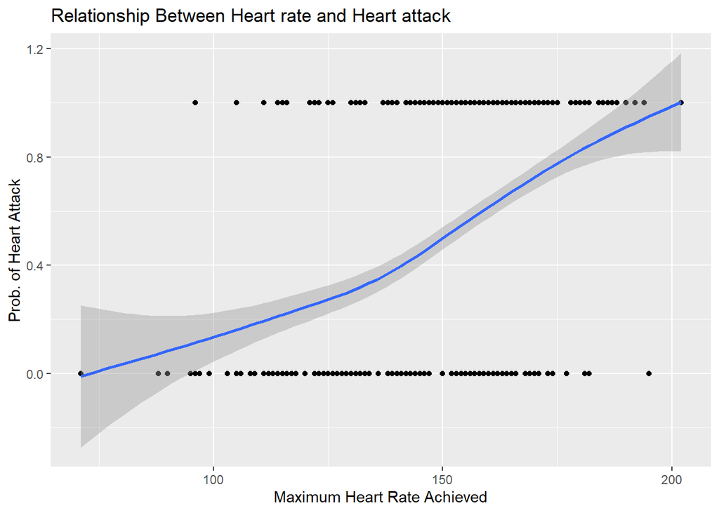

```r
ggplot(heart,aes(x=thalach,y=target))+geom_point()+geom_smooth()+
    scale_x_continuous(name="Maximum Heart Rate Achieved")+
    scale_y_continuous(name="Prob. of Heart Attack")+
    ggtitle("Relationship Between Heart rate and Heart attack")
```

# Exercise Induced Angina

Angine is a type of Chest Pain caused by induced flow of blood to heart. This variable is categorical(Two category 0 and 1) where 0 means no Exang.

```r
k=table(heart$exang,heart$target)
k
```

```
##
##       0   1
##   0 225 455
##   1 274  71
```

We can clearly see in stacked barplot that people with no Exang is more likely to get Heart Attack.

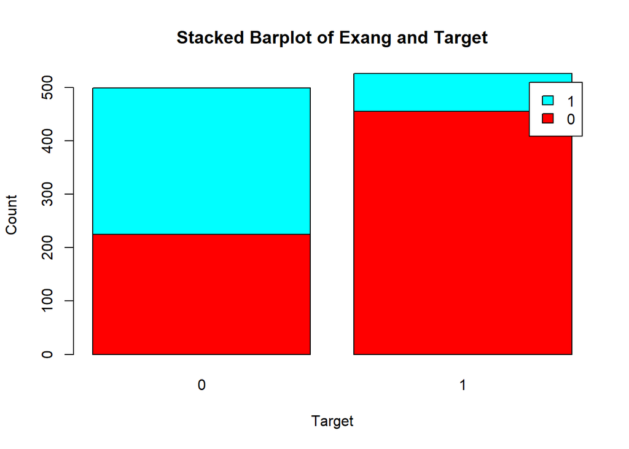

```r
barplot(k,
       legend=rownames(k),
       col=rainbow(2),
       main="Stacked Barplot of Exang and Target",
       xlab="Target",
       ylab="Count")
```

# OldPeak Analysis

Oldpeak is ST depression induced by exercise relative to rest. This variable is numeric with minimum being 0 and maximum 6.200.

```r
summary(heart$oldpeak)
```

```
##    Min. 1st Qu.  Median    Mean 3rd Qu.    Max.
##   0.000   0.000   0.800   1.072   1.800   6.200
```

We can see in Histogram maximum population is lying between 0 and 0.5 .

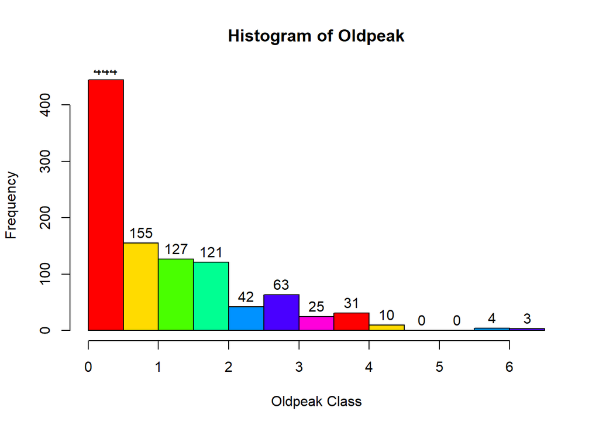

```r
hist(heart$oldpeak,
    main="Histogram of Oldpeak",
    xlab="Oldpeak Class",
    ylab="Frequency",
    col=rainbow(7),
    labels=TRUE)
```

Data is right skewed, not normally distributed.

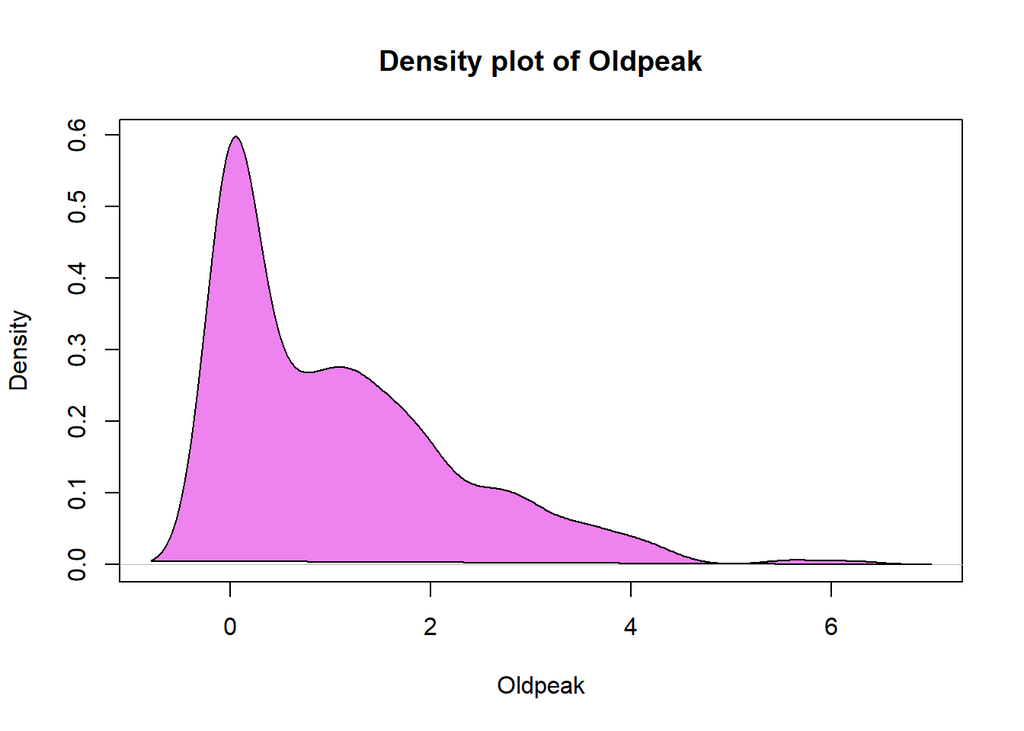

```r
plot(density(heart$oldpeak),
    main="Density plot of Oldpeak",
    xlab="Oldpeak",
    ylab="Density")
polygon(density(heart$oldpeak),col="violet",border="black")
```

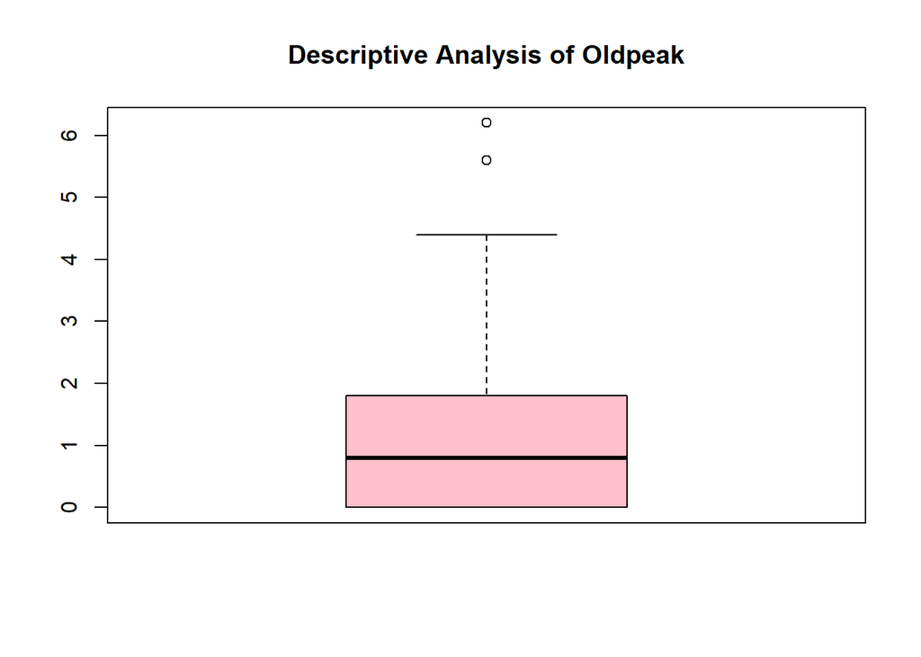

```r
boxplot(heart$oldpeak,main="Descriptive Analysis of Oldpeak",col="pink")
```